# ggplot2 introduction

That’s because we need to convert `cyl` to a factor:

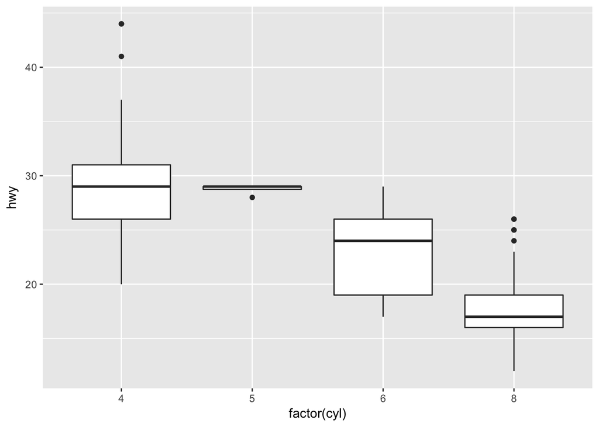

Another type of visualization I use a lot for visualizing distributions is the violin plot:

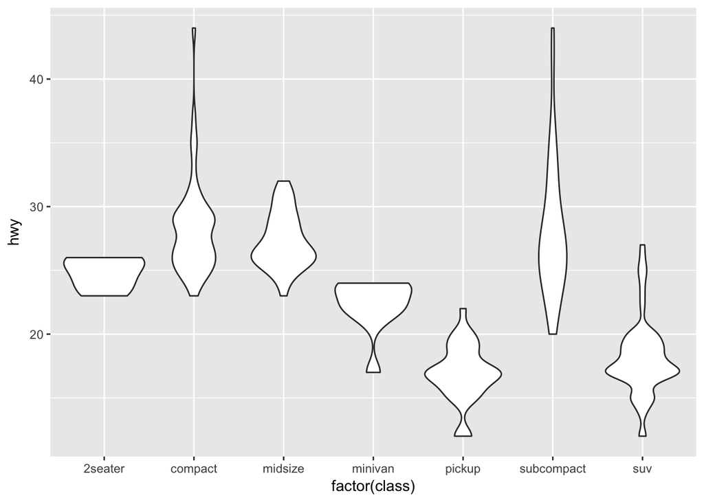

So far we’ve made really simple plots: One geometry per plot. Let’s layer multiple geometries on top of one another to show the raw points on top of the violins:

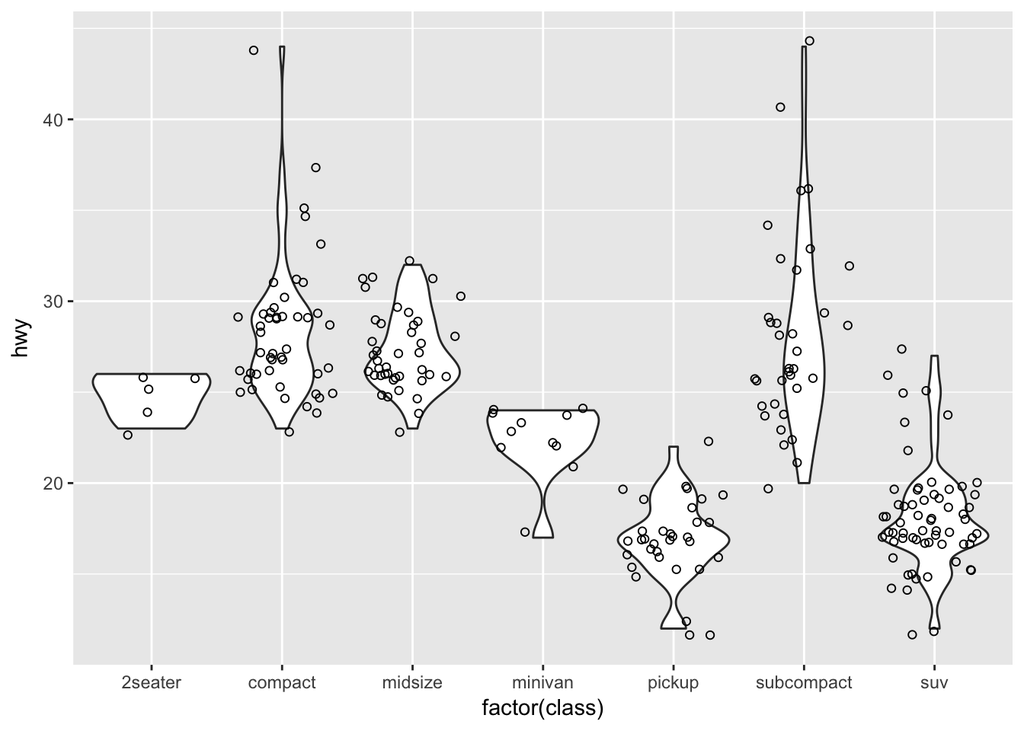

ggplot2 also helps us do some quick-and-dirty modeling:

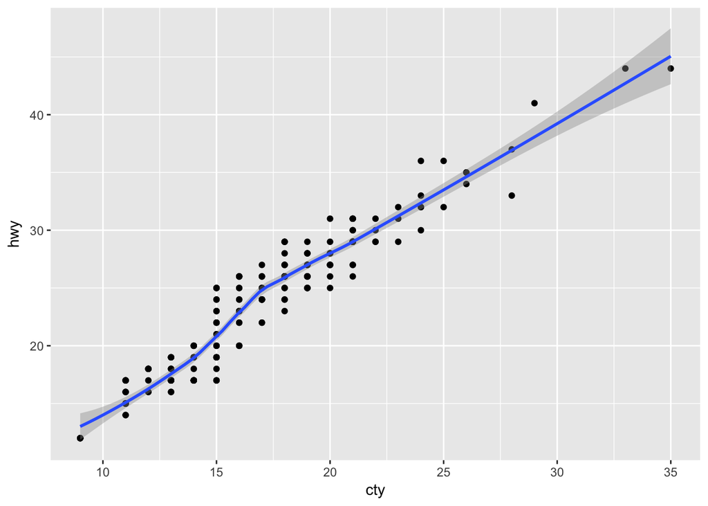

`geom_smooth()` is pretty configurable. Here we set the method to `lm` instead of the default `loess`:

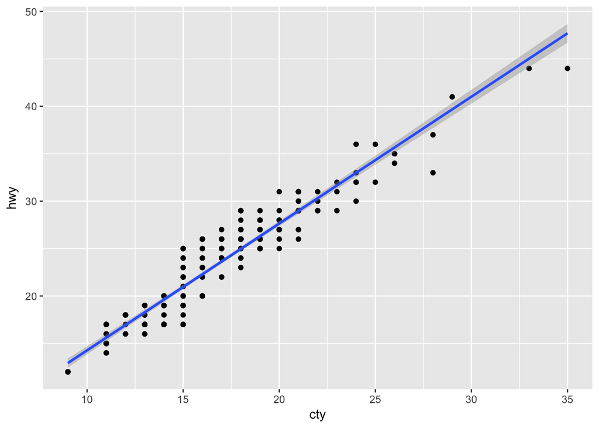

### coordinates

Every plot you make has a coordinate space. Most often this is the Cartesian (XY) plane. But we can also plot our data in other scales, like log10:

Here’s some census data, unscaled:

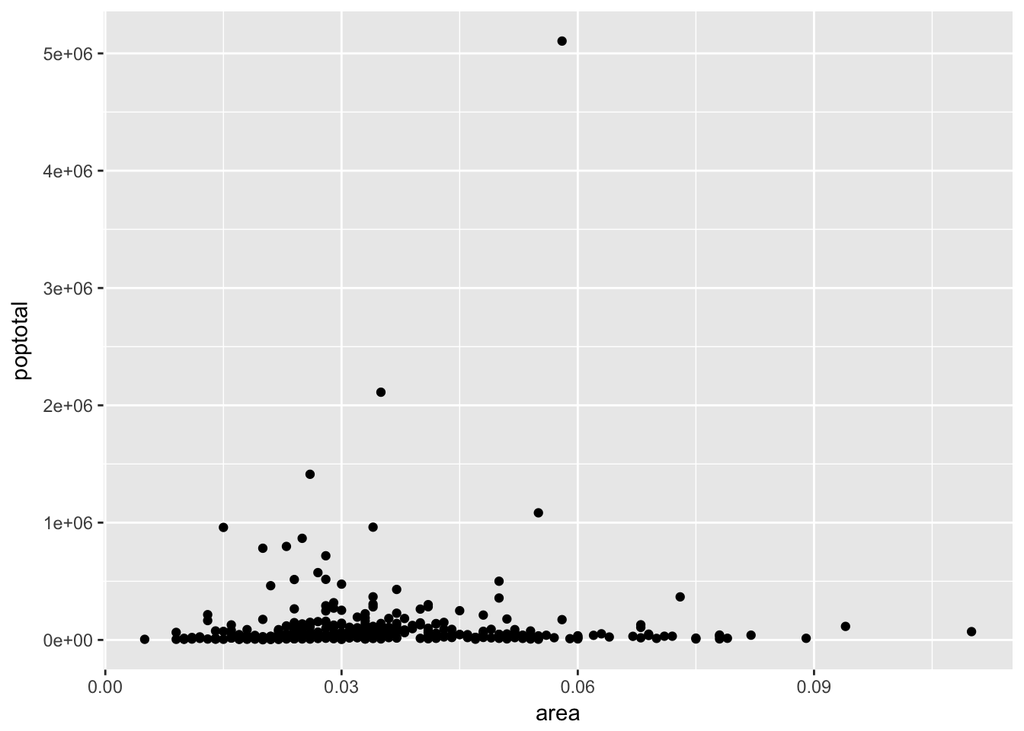

And scaled (log10):

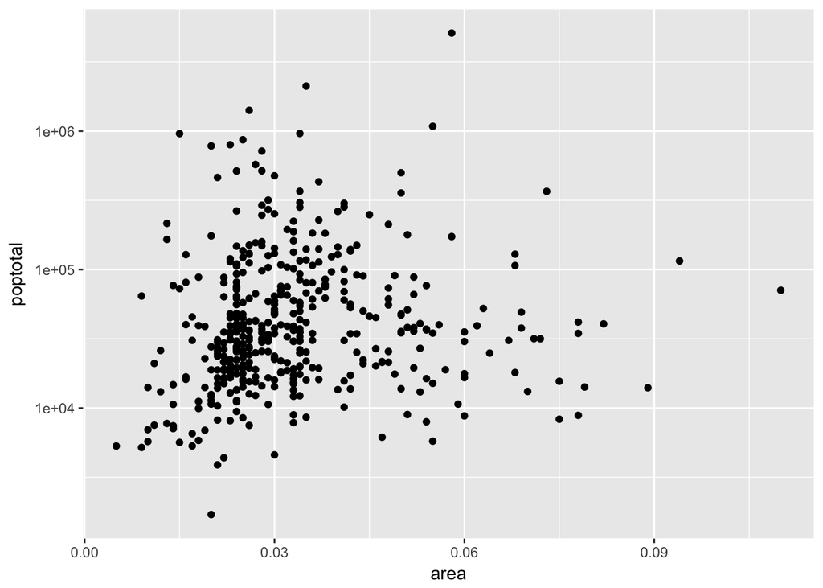

#### Setting plot limits

Plot limits can be controlled one of three ways:

- Filter the data (because limits are auto-calculated from the data ranges)
- Set the `limits` argument on one or both scales
- Set the `xlim` and `ylim` arguments in `coord_cartesian`

Let’s show this with an example plot:

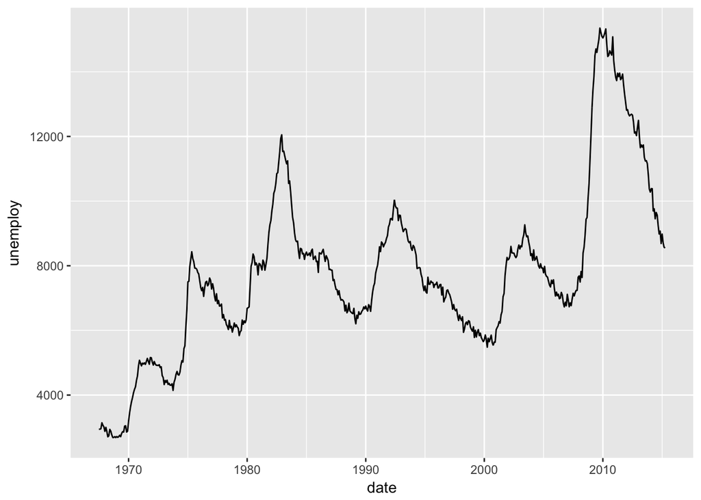

Since we’re plotting data where the zero point on the vertical axis means something, maybe we want to start the vertical axis at 0:

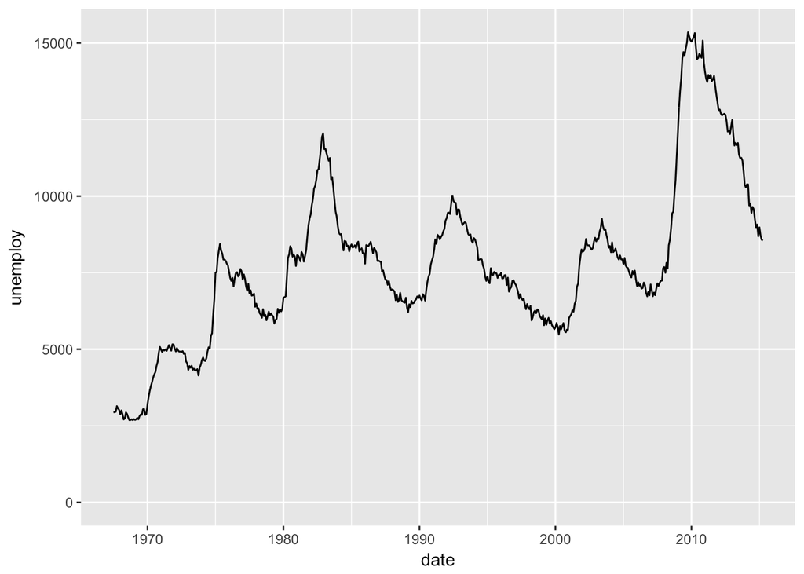

Or maybe we want to zoom in on just the 2000’s and beyond:

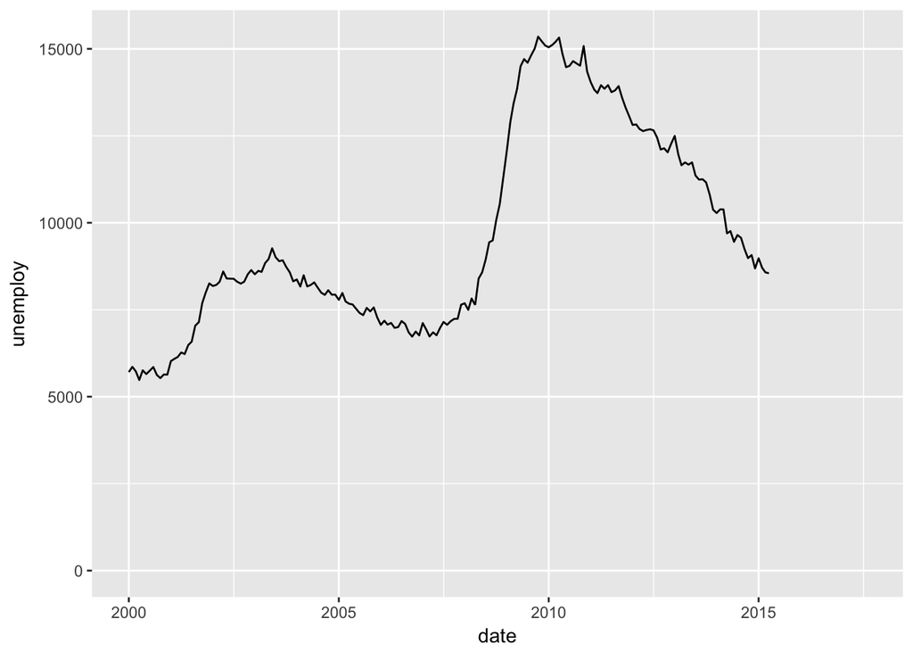

Note the warning message we received:

> Warning message: Removed 390 rows containing missing values (geom_path).

That’s normal when data in your input data.frame are outside the range we’re plotting.

Let’s use `coord_cartesian` instead to change the x and y limits:

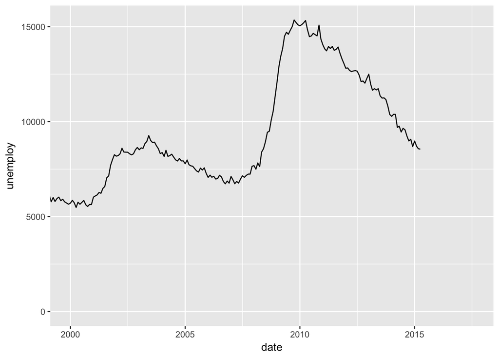

Note the **slight* difference when using `coord_cartesian`: ggplot didn’t put a buffer around our values. Sometimes we want this and sometimes we don’t and it’s good to know this difference.

### scales

- show the format: scale_{aesthetic}_{method}

scale_colour_viridis() - axis ticks - axis limits - continuous scales - date scales - discrete scales - log scales

### plot customization

#### titles

#### axes

#### themes

more themes at https://github.com/jrnold/ggthemes legend layout / hiding

### facets

### saving plots

### maps with ggplot2

## Resources

- Multiple graphs in a single graph:
- http://www.cookbook-r.com/Graphs/Multiple_graphs_on_one_page_(ggplot2)/
- cowplot: https://cran.r-project.org/web/packages/cowplot/vignettes/introduction.html
- http://www.cookbook-r.com/Graphs/
- Book on ggplot: https://www.amazon.com/dp/331924275X/ref=cm_sw_su_dp
- Source code: https://github.com/hadley/ggplot2-book